# PakPC2023: Pakistan data from Pakistan Population Census 2023

Muhammad Yaseen

2024-11-01

# 1 Introduction

The [Pakistan Bureau of Statistics (PBS)](https://www.pbs.gov.pk/) holds the pivotal responsibility of orchestrating, collating, and disseminating the outcomes of the population census within the nation. On the significant date of August 5, 2023, the Council of Common Interests (CCI) accorded its approval for the findings derived from the Census of 2023, a comprehensive endeavor led by the PBS to capture the demographic landscape of Pakistan. To facilitate widespread access to this crucial data, the PBS published the conclusive results of the Census 2023 on its [official website](https://www.pbs.gov.pk/) in a PDF format, albeit one that is not machine-readable.

However, this presentation in PDF form poses a significant challenge to researchers and analysts aiming to delve into the insights embedded within this valuable data. The intricacies of extracting, processing, and interpreting information from a non-machine-readable format like PDF hinder the swift utilization of this data for in-depth analysis. Recognizing this impediment, a strategic solution has been crafted in the form of an R programming language package termed PakPC2023.

The PakPC2023 R package has been meticulously developed to surmount the obstacles presented by the non-machine-readable PDF format. This specialized software acts as a bridge, effectively converting the cumbersome PDF-based Census 2023 data into a format that is amenable for analysis within the R software environment. Researchers, analysts, and data enthusiasts can seamlessly install the PakPC2023 package from the Comprehensive R Archive Network (CRAN), a repository that serves as a hub for R packages, ensuring easy accessibility to this innovative tool.

By implementing the PakPC2023 package, the door is opened for researchers to harness the power of the Census 2023 data in an efficient and effective manner. This strategic initiative not only streamlines the process of accessing and utilizing the census data but also empowers researchers to unlock valuable insights and trends that lie within, contributing to informed decision-making and comprehensive socio-economic understanding.

## 1.1 Province Level

|  | Region | Area | Households | Pop2023 | AHS | Pop2017 | GR |
| --- | --- | --- | --- | --- | --- | --- | --- |
| 1 | Pakistan | All | 38340566 | 241499431 | 6.3 | 207684626 | 2.55 |
| 2 | Pakistan | Rural | 23323551 | 147748707 | 6.33 | 132013789 | 1.9 |
| 3 | Pakistan | Urban | 15017015 | 93750724 | 6.24 | 75670837 | 3.65 |
| 4 | Punjab | All | 19855902 | 127688922 | 6.430000000000001 | 109989655 | 2.53 |
| 5 | Punjab | Rural | 11719520 | 75715270 | 6.46 | 69442450 | 1.46 |
| 6 | Punjab | Urban | 8136382 | 51973652 | 6.39 | 40547205 | 4.24 |
| 7 | Sindh | All | 9871620 | 55696147 | 5.64 | 47854510 | 2.57 |
| 8 | Sindh | Rural | 4744589 | 25771071 | 5.430000000000001 | 23021876 | 1.9 |
| 9 | Sindh | Urban | 5127031 | 29925076 | 5.84 | 24832634 | 3.17 |
| 10 | KP | All | 5883007 | 40856097 | 6.94 | 35501964 | 2.38 |

[output cut: 8 more lines]

The visual representation presented in Figure 1.1 provides a comprehensive overview of the population distribution across various regions of Pakistan. This data has been meticulously collected from the Pakistan Population Census of 2023, serving as an accurate reflection of the demographic landscape of the country.

A closer examination of the graph reveals that the province of Punjab emerges as the most populous region, boasting an impressive population count of approximately 128 million individuals. Following closely, the province of Sindh contributes significantly to the nation’s population with approximately 56 million residents.

Turning our attention towards the remaining regions, Khyber Pakhtunkhwa stands as a substantial population center with around 41 million inhabitants, further emphasizing its role in the overall demographic makeup of Pakistan. On the other hand, Balochistan, while having a comparably smaller population, still contributes notably with around 15 million people.

It is noteworthy that the data showcased in Figure 1.1 not only underscores the population sizes of these regions but also underscores the diversity and complexity of Pakistan’s demographic distribution. This information serves as a valuable resource for policymakers, researchers, and anyone interested in gaining insights into the population dynamics of Pakistan.

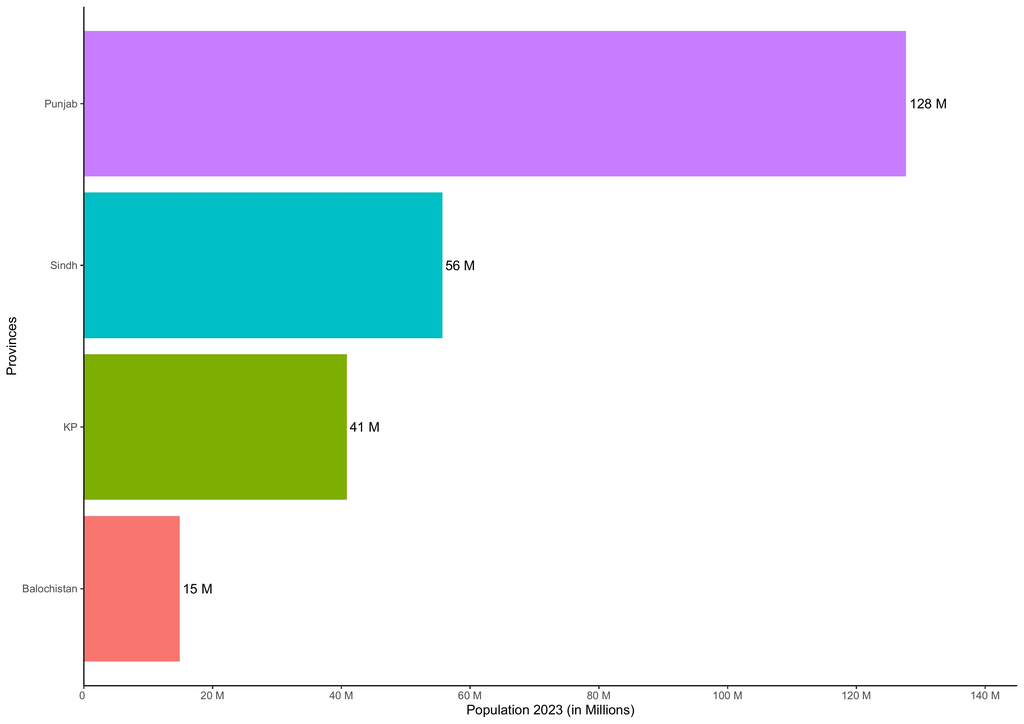

Figure 1.1: Population by Regions

Figure 1.2 illustrates the distribution of Pakistan’s population across various regions and areas, providing insights drawn from the Pakistan Population Census 2023. The data underscores a significant urban-rural divide within the country, shedding light on the demographic landscape.

Notably, the data reveals that a substantial portion of Pakistan’s population resides in rural areas, accounting for a staggering figure of more than 147.75 million individuals. In contrast, the urban population stands at slightly over 93.75 million. This distribution underscores the predominance of rural living conditions in Pakistan.

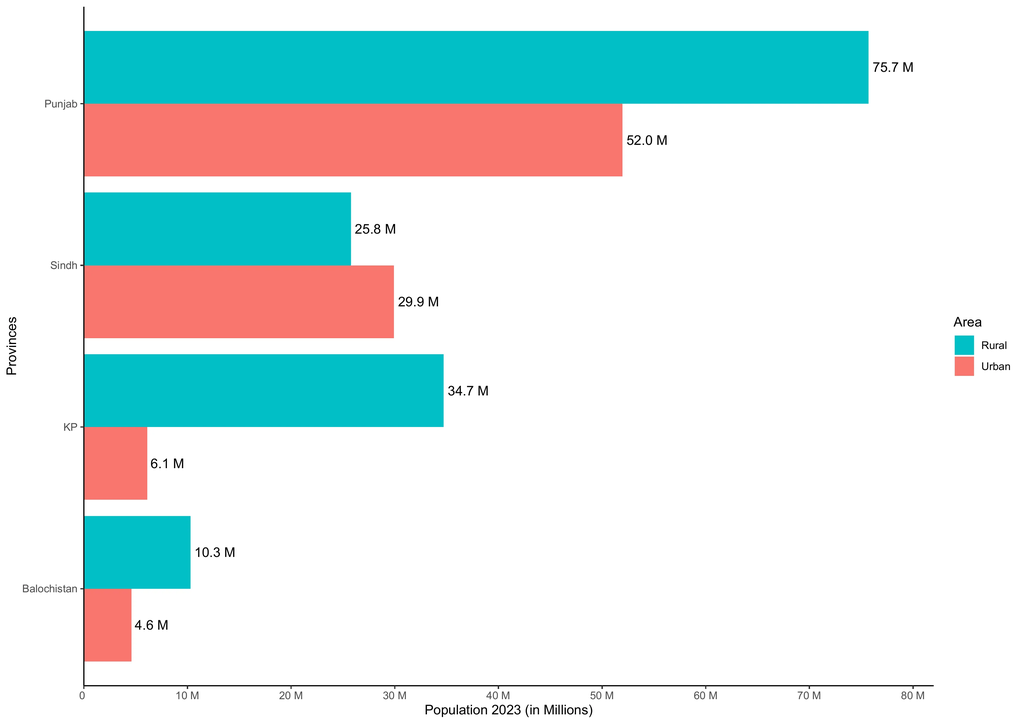

Figure 1.2: Population by Regions & Area

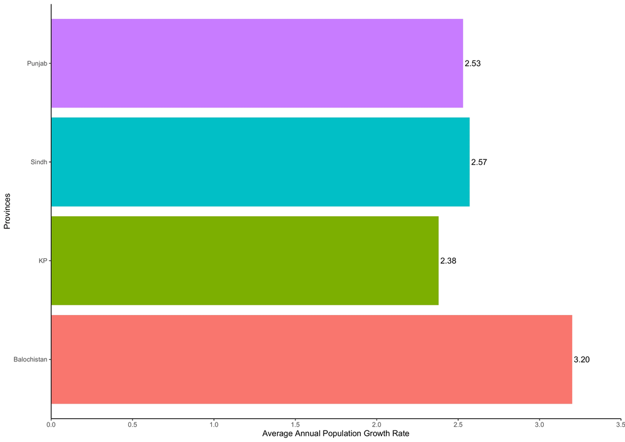

Figure 1.3: Fig. 3: Average Annual Population Growth Rate by Regions

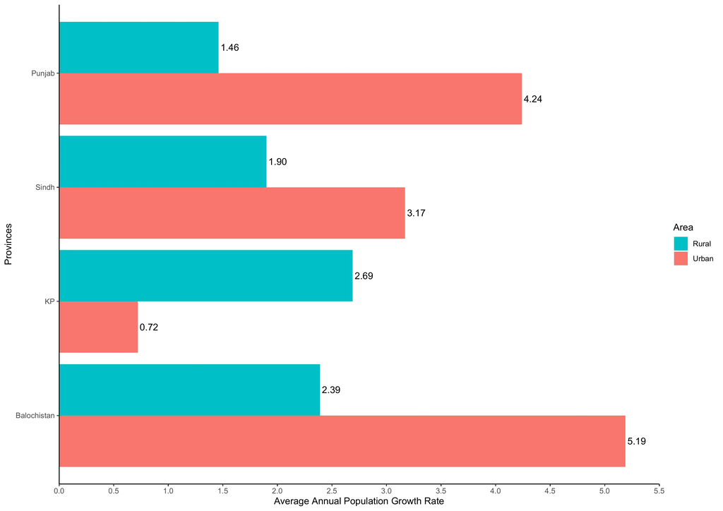

Figure 1.4: Fig. 4: Average Annual Population Growth Rate by Regions & Area

## 1.2 Division Level

|  | Region | Division | Households | Pop2023 | AHS | Pop2017 | GR |
| --- | --- | --- | --- | --- | --- | --- | --- |
| 1 | Punjab | Bahawalpur | 2060013 | 13400009 | 6.5 | 11452594 | 2.66 |
| 2 | Punjab | Dera Ghazi Khan | 1955041 | 12892465 | 6.59 | 11021214 | 2.66 |
| 3 | Punjab | Faisalabad | 2527950 | 16228526 | 6.42 | 14185231 | 2.27 |
| 4 | Punjab | Gujranwala | 2775775 | 18778868 | 6.77 | 16120861 | 2.58 |
| 5 | Punjab | Lahore | 3498991 | 22772710 | 6.51 | 19389856 | 2.72 |
| 6 | Punjab | Multan | 2281317 | 14085102 | 6.17 | 12268173 | 2.33 |
| 7 | Punjab | Rawalpindi | 1871806 | 11406496 | 6.09 | 10006624 | 2.21 |
| 8 | Punjab | Sahiwal | 1341588 | 8533471 | 6.359999999999999 | 7378065 | 2.46 |
| 9 | Punjab | Sargodha | 1543421 | 9591275 | 6.21 | 8167037 | 2.72 |
| 10 | Sindh | Hyderabad | 2246096 | 11659246 | 5.19 | 10596049 | 1.61 |

[output cut: 21 more lines]

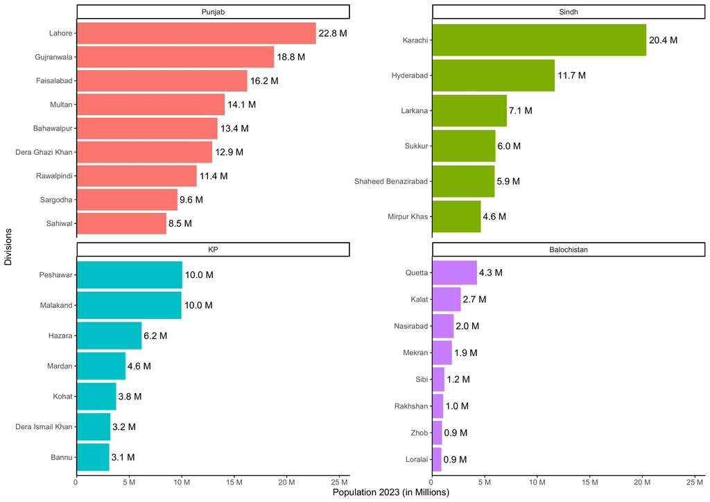

Figure 1.5: Fig. 5: Population by Regions & Division

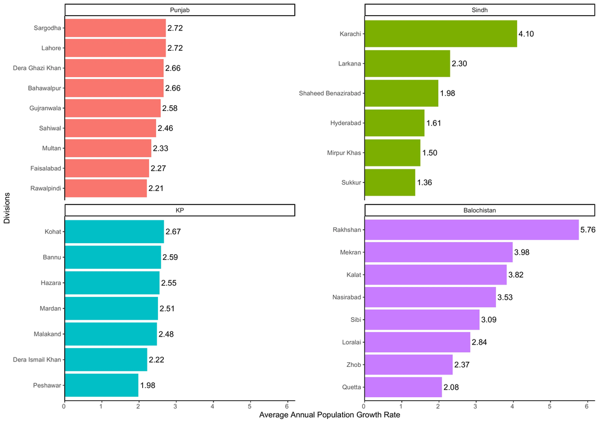

Figure 1.6: Fig. 6: Average Annual Population Growth Rate by Regions & Division

## 1.3 District Level

|  | Region | Division | District | Households | Pop2023 | AHS | Pop2017 | GR |
| --- | --- | --- | --- | --- | --- | --- | --- | --- |
| 1 | Punjab | Bahawalpur | Bahawalnagar | 558333 | 3550342 | 6.359999999999999 | 2975656 | 3 |
| 2 | Punjab | Bahawalpur | Bahawalpur | 674155 | 4284964 | 6.359999999999999 | 3669176 | 2.63 |
| 3 | Punjab | Bahawalpur | Rahim Yar Khan | 827525 | 5564703 | 6.72 | 4807762 | 2.47 |
| 4 | Punjab | Dera Ghazi Khan | Dera Ghazi Khan | 454711 | 3393705 | 7.46 | 2872631 | 2.83 |
| 5 | Punjab | Dera Ghazi Khan | Layyah | 341276 | 2102386 | 6.159999999999999 | 1823995 | 2.4 |
| 6 | Punjab | Dera Ghazi Khan | Muzaffargarh | 804783 | 5015325 | 6.23 | 4328549 | 2.49 |
| 7 | Punjab | Dera Ghazi Khan | Rajanpur | 354271 | 2381049 | 6.72 | 1996039 | 2.99 |
| 8 | Punjab | Faisalabad | Chiniot | 256660 | 1563024 | 6.09 | 1368659 | 2.24 |
| 9 | Punjab | Faisalabad | Faisalabad | 1384668 | 9075819 | 6.55 | 7882444 | 2.38 |
| 10 | Punjab | Faisalabad | Jhang | 494761 | 3077720 | 6.22 | 2742633 | 1.95 |

[output cut: 126 more lines]

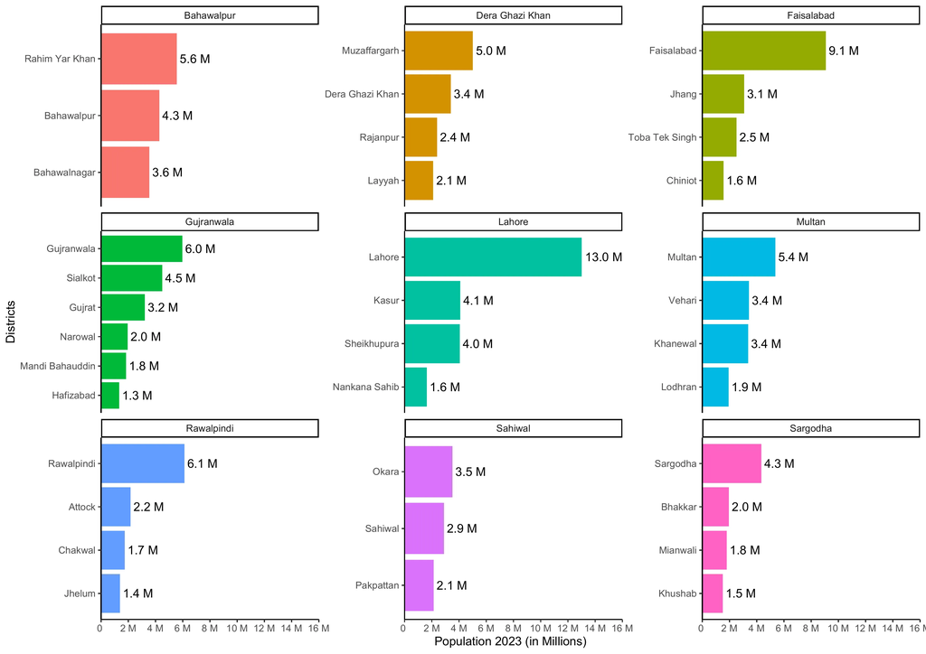

Figure 1.7: Fig. 7: Population by Division & District for Punjab

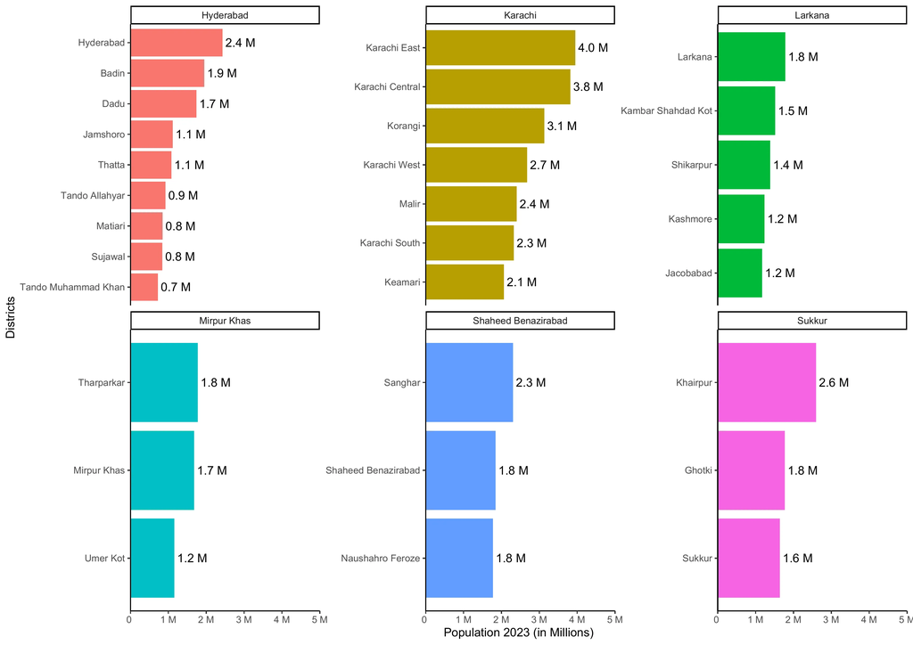

Figure 1.8: Fig. 8: Population by Division & District for Sindh

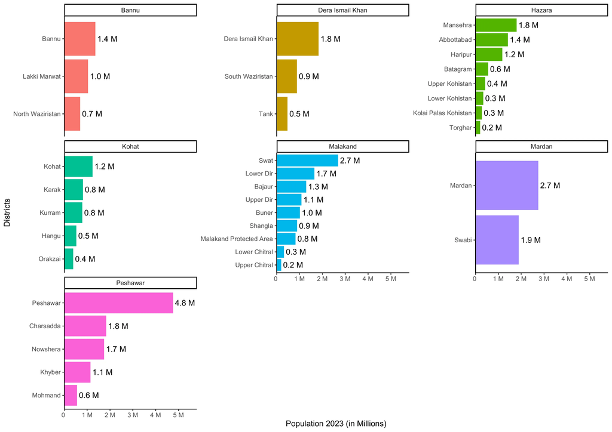

Figure 1.9: Fig. 9: Population by Division & District for KP

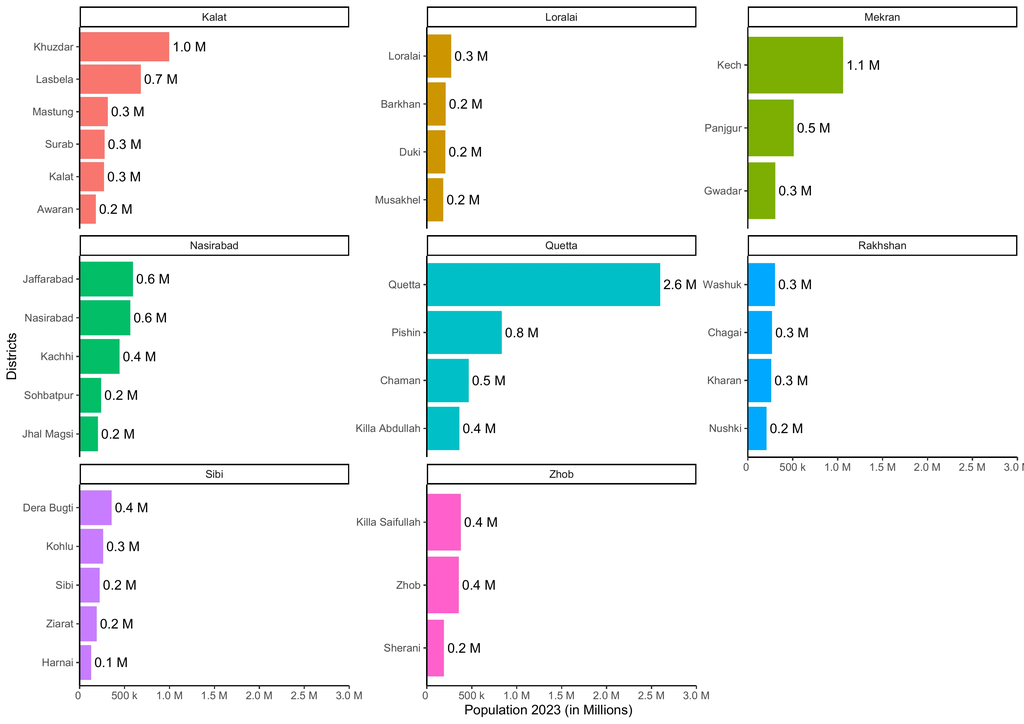

Figure 1.10: Fig. 10: Population by Division & District for Balochistan

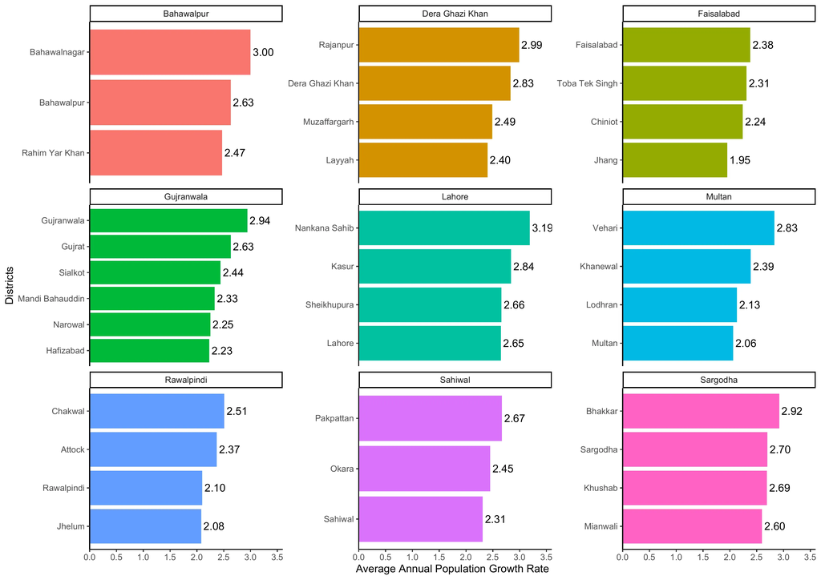

Figure 1.11: Fig. 11: Average Annual Population Growth Rate by Division & District for Punjab

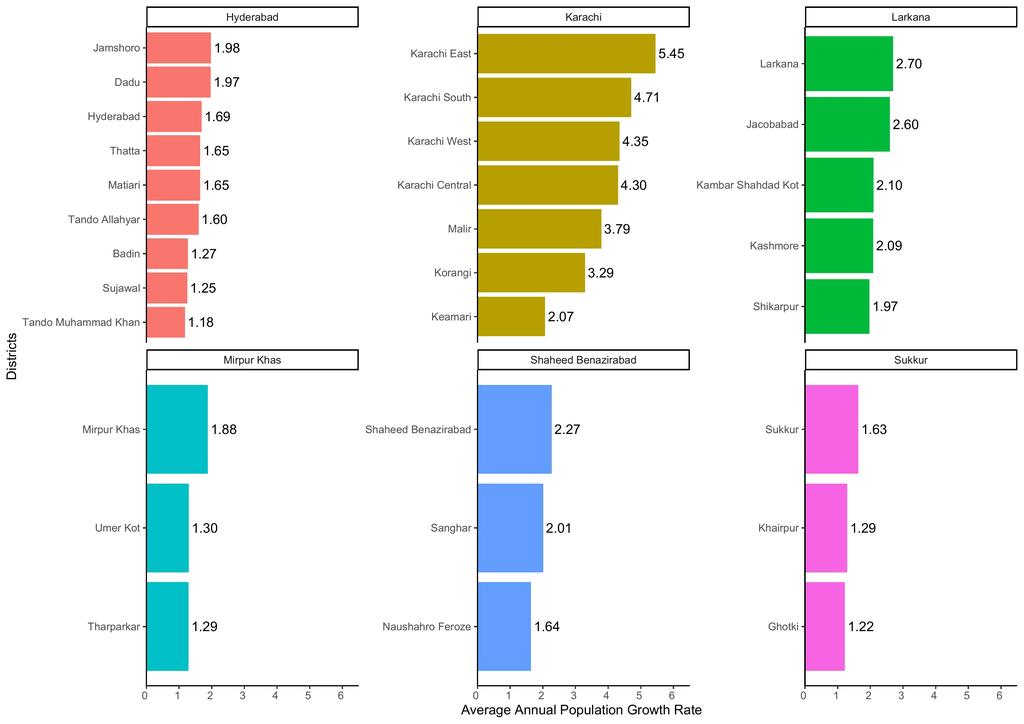

Figure 1.12: Fig. 12: Average Annual Population Growth Rate by Division & District for Sindh

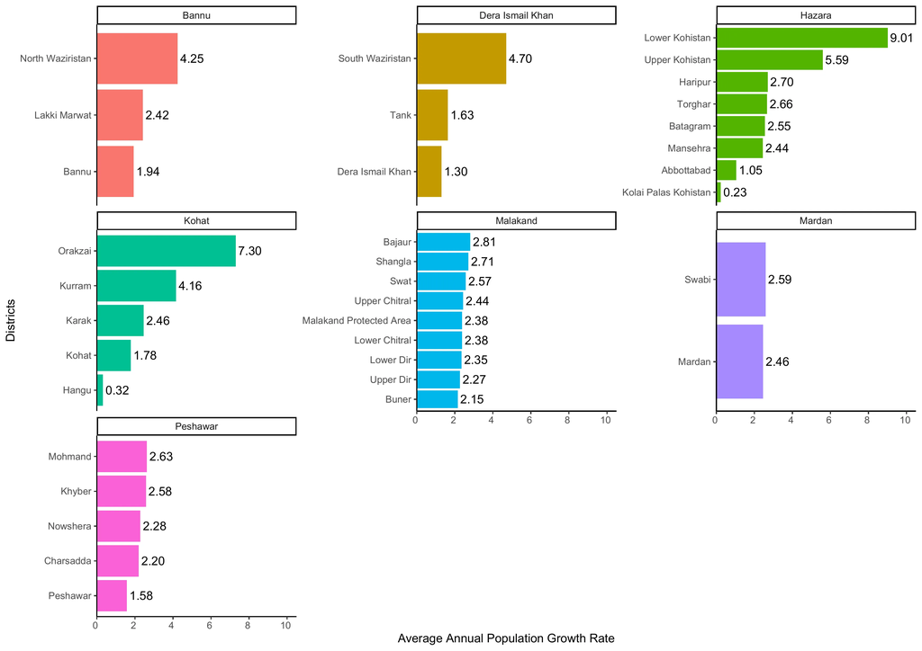

Figure 1.13: Fig. 13: Average Annual Population Growth Rate by Division & District for KP

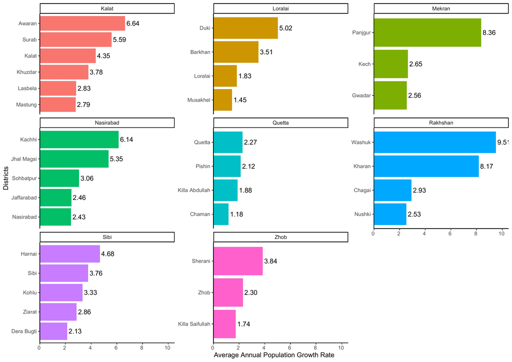

Figure 1.14: Fig. 14: Average Annual Population Growth Rate by Division & District for Balochistan